# 第3回 回帰分析（単回帰・最小二乗・決定係数）

経済データとプログラミングII

第3回

回帰分析

点の散らばりに、線を 1 本引く

経済データとプログラミングII

第3回 — Topic01

散布図と単回帰

2 つの列の関係を、1 本の線で言う

## 第3回の道のり

1

線を引く

演習 3-1

散布図と例の線

2

線の選び方

写経

二乗和を出す

3

機械に引かせる

演習 3-3

予測と二乗和

4

当たり具合

演習 3-4

期間と決定係数

いまココ — 2 つの列を 1 枚の図にして、1 本の線で言う

## 前の回の振り返り

前の回のポイント

Q: 前の回は、表の列をどう見たか

- **1 列ずつ**: 1 つの列の値がどこに集まるかを、ヒストグラムで見た
- **1 本の図**: 箱ひげ図で、真ん中・散らばり・離れた値を読んだ
- **まだ見ていないこと**: 2 つの列が一緒にどう動くか

今日は 2 列を一緒に見る。片方が大きいとき、もう片方はどうなるか

## 回帰から始める理由

- **何を**：この授業は、まず**回帰**から入る
- **なぜ**：回帰は機械学習の**いちばん簡単な例**。  
  仕組みが見やすい形で出る
- **何が見えるか**：データに**当てはめる**／当てはめ**すぎる**（過学習）
- **いつ効くか**：この 2 つの話は、  
  木の形をした手法にもニューラルネットにも出てくる（名前だけ）

簡単な例で分かった仕組みは、大きな手法でもそのまま効く

## このトピックで学ぶこと

- **何をやるか**：2 つの列を 1 枚の図にし、1 本の線の式で言う
- **なぜ**：表の数字を上から読むだけでは、2 つの列の関係が見えない
- **いつ必須か**：卒論やレポートで「A と B の関係」を書くとき
- **最後に**：失業率と物価上昇率で、点と線を自分の Colab で描く

問い：架空の 5 人。バイトの多い人ほど、自習は短い？

## 架空の 5 人の表

架空の 5 人の 1 週間。アルバイトの日数と、自習の時間

| 人 | アルバイト日数 $x$（日） | 自習時間 $y$（時間） |
| --- | --- | --- |
| A | 1 | 9 |
| B | 2 | 10 |
| C | 3 | 6 |
| D | 4 | 2 |
| E | 5 | 3 |

1 行＝1 人。数字を上から読むだけでは、関係はつかみにくい

## 1 行ずつ打つ点

[figure not shown]

1 行を 1 点に。横の位置は日数 $x$、縦の位置は時間 $y$

## 散布図

定義

**散布図**＝2 つの列の組を、1 行 1 点で表した図

- **横の軸**：説明に使う列 $x$（いまはアルバイト日数）
- **縦の軸**：当てたい列 $y$（いまは自習時間）
- **読むもの**：点の並びの向き。右下がりなら、  
  $x$ の大きい人ほど $y$ が小さい

5 人の点は右下がり。バイトの多い人ほど、自習が短い

## 失業率と物価上昇率のデータ

今度は日本の**失業率**と、コア CPI の伸び＝**物価上昇率**をくらべる

| 系列 | 列名 | 中身 |
| --- | --- | --- |
| **完全失業率** | `unemployment_rate` | 仕事を探しているのに、 仕事に就けていない人の 割合（%） **季節調整済** ＝ 毎年きまって 出る上下をならした数 |
| **コア CPI** | `cpi_core_yoy` | **生鮮食品を除く**消費者 物価の、1 年前と比べた 伸び（%） |

月ごとの数を年ごとに平均し、1991〜2026 年の 36 年ぶん（2026 年は 1〜5 月）

## データを読む準備のセル

```python
!pip install -q japanize-matplotlib
import japanize_matplotlib
import matplotlib.pyplot as plt
import pandas as pd
BASE = "ここに manaba の URL を貼る"
u = pd.read_csv(BASE + "unemployment_sa_monthly.csv", parse_dates=["date"])
c = pd.read_csv(BASE + "cpi_core_yoy_monthly.csv", parse_dates=["date"])
df = pd.merge(u, c, on="date").set_index("date")
df = df.resample("YS").mean()
print(len(df))
df.head(3)
```

| 行 | 書き方 | 意味 |
| --- | --- | --- |
| 1-4 | 道具を呼ぶ | 図の日本語・図の道具 `plt`・表の道具 `pd` |
| 5 | `BASE = "…"` | 中を消し、URL の**最後の / まで**を貼る（CSV を上げたら `""`） |
| 6-9 | 読む・つなぐ・年平均 | 2 本の CSV を日付でつなぎ、年ごとの平均の表 `df` に |
| 10-11 | 確かめる | 行の数 36 と、先頭の 3 行 |

**写経せず、そのまま実行するセル**。変えるのは 5 行目だけ

## 36 年の表の先頭

セルの下に 36 と、この 3 行が出る（ここでは小数第 2 位に丸めて見せる）

| date（年の初め） | `unemployment_rate`（%） | `cpi_core_yoy`（%） |
| --- | --- | --- |
| 1991-01-01 | 2.09 | 2.88 |
| 1992-01-01 | 2.15 | 2.25 |
| 1993-01-01 | 2.50 | 1.26 |

1 行＝1 年。5 人の表の 1 行＝1 人と同じ読み方

## 36 年の散布図

[figure not shown]

1 年が 1 点。36 点の並びも右下がり

## 写経 1 散布図のコード

```python
plt.scatter(df["unemployment_rate"], df["cpi_core_yoy"])
plt.xlabel("失業率（%）")
plt.ylabel("物価上昇率（%）")
plt.show()
```

| 行 | 部品 | 渡すもの | 返ってくるもの・起きること |
| --- | --- | --- | --- |
| 1 | **① 点を打つ** `plt.scatter` | 横の列、縦の列（この順） | 1 年を 1 点にした散布図 |
| 2-3 | **② 軸名** | 横・縦の軸に書く文字 | 軸に名前が付く |
| 4 | **③ 表示** | 何も渡さない | セルの下に図が出る |

※ 先に書いた列が横、後に書いた列が縦  
※ **`"` は半角。全角の `”` だとエラー**

## コードセルの写経と実行

1. **＋ コード**で空のセルを足す  
   （案内の文の下）
2. 写経 1 の 4 行を上  
   から写す
3. **▶** か **Shift + Enter** で実行  
   （Mac は Shift + return）
4. セルの下に 36 点の散布  
   図が出るかを見る

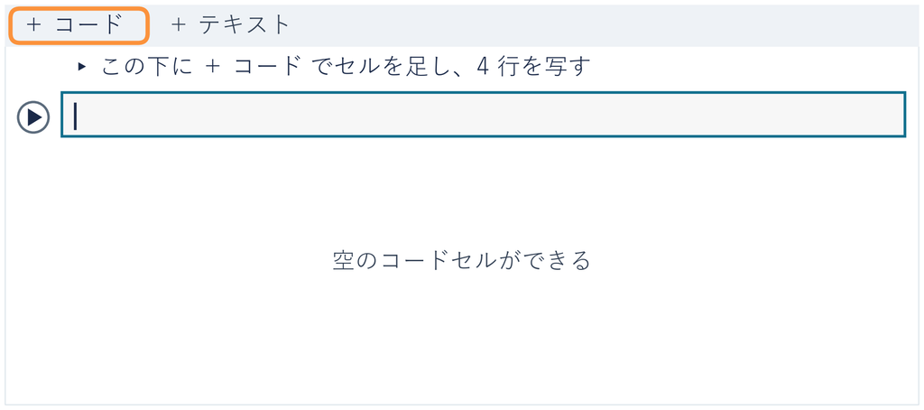

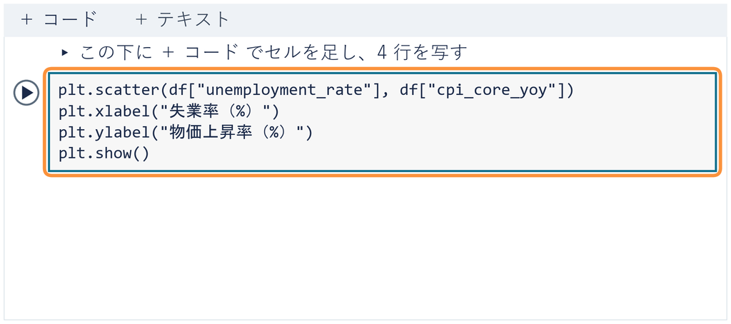

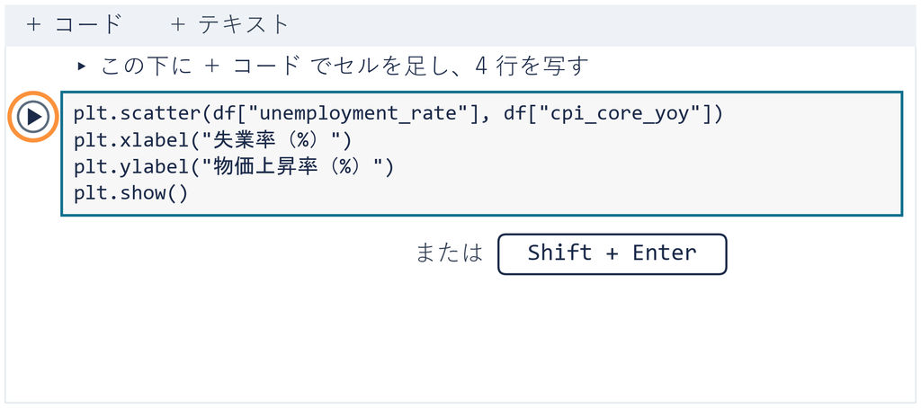

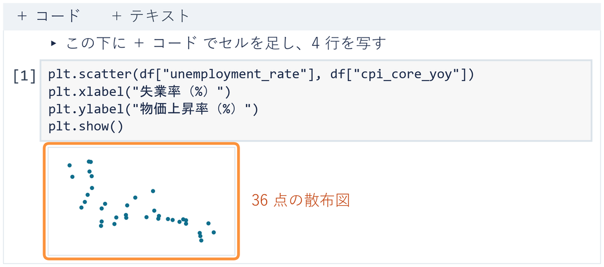

⏸ PAUSE 動画を止めて $2$ 分。図が出たら再生に戻る

## 演習 3-1-1 横と縦の入れ替え

演習 3-1-1

横と縦の列を入れ替えると、点の並びはどうなるか

```python
plt.scatter(df["unemployment_rate"], df["cpi_core_yoy"])
plt.show()
```

1. **先に考える**：ⓐ 右下がりのまま ⓑ 右上がりに変わる
2. **写して変える**：案内の下に **＋ コード** でセルを足して写す  
   1 行目の 2 つの列の順を入れ替える（1 か所）。写経のセルは残す
3. **終わり**：ⓐ か ⓑ を答え欄に書く ※ `"` は半角  
   答え欄 ＝ 案内の下の文のセル

⏸ PAUSE 動画を止めて $3$ 分。答えを書いたら再生に戻る

## 演習 3-1-1 の答え

答えは **ⓐ 右下がりのまま**。縦と横が入れ替わるだけ

[figure not shown]

どちらを横に置くか ＝ どちらで説明するか。今日は失業率を横に置く

## ◼ 単回帰の直線

定義

**単回帰**の直線
$$\hat{y} = \hat{\beta}_0 + \hat{\beta}_1 x$$

- $\hat{y}$：**線の値**。$x$ を式に入れて出す。$y$ は実際の値
- $\hat{\beta}_0$：**切片**。$x = 0$ のときの線の高さ
- $\hat{\beta}_1$：**傾き**。$x$ が $1$ 増えたときの $\hat{y}$ の動き。**負なら下がる**
- $\beta$ は**係数**に使うギリシャ文字。上の山の印**ハット**は、データから**決めた値**の印

**回帰** ＝ 当てたい列 $y$ を、別の列 $x$ の式で当てること。**単回帰**は $x$ が 1 列だけ

## 5 人の雲に引く線

[figure not shown]

例として $\hat{y} = 12 - 2x$（$\hat{\beta}_0 = 12$・$\hat{\beta}_1 = -2$）。C さんのほかは、  
実際の時間が線の値とずれる

## 傾きと切片の読み

[figure not shown]

傾き −2：1 日多い人ほど、平均して 2 時間短い。  
切片 12：0 日のときの線の高さ

## 36 年に引く例の線

今度は 36 年。同じ形の式で、例として目で 1 本置く

[figure not shown]

失業率 3.0% の年の線の値は、4.0 − 1.0 × 3.0 ＝ 1.0

## 経済の言葉で読む傾き

読み方

例の線の傾き −1.0 ＝  
「この線では、失業率が 1 ポイント高い年ほど、  
線の値が 1.0 ポイント低い」

- **単位は %ポイント**：% どうしの**差**を言う単位
- **身近な例**：消費税が $8$% から $10$% へ ＝ $2$ **%ポイント**上がった（率で言えば $25$% 増）
- **切片 4.0**：失業率 0% の年の線の値。そんな年は無いので、  
  切片だけを取り出して読まない

卒論で「A と B の関係」を書くとき、散布図の次によく来るのがこの 1 行

## よくある失敗 傾きの因果の読み違え

✕ マイナスなら、下げれば上がる

傾きがマイナスなら、  
失業率を下げれば物価が上がる

式が右下がりなので、  
そう読みたくなる

○ 一緒に動いた、までが言えること

直線が言うのは  
「**2 つが逆向きに動いた**」

片方を動かすともう片方が動く、  
とは言っていない

前に出てきた「関連であって因果ではない」  
（一緒に動いた ≠ 片方が原因）が、ここでも効く

## 写経 2 例の線のコード

```python
b0 = 4.0  # 切片
b1 = -1.0  # 傾き
pred = b0 + b1 * df["unemployment_rate"]
plt.scatter(df["unemployment_rate"], df["cpi_core_yoy"])
plt.plot(df["unemployment_rate"], pred)
plt.xlabel("失業率（%）")
plt.ylabel("物価上昇率（%）")
plt.show()
```

| 行 | 部品 | 渡すもの | 返ってくるもの・起きること |
| --- | --- | --- | --- |
| 1-2 | **① 切片と傾き** | 切片 4.0 と傾き −1.0 | 切片に `b0`、傾きに `b1` の名前 |
| 3 | **② 線の値** | 失業率を線の式に入れる | 36 個の線の値に `pred` の名前 |
| 4 | **③ 点を打つ** | 写経 1 と同じ | 36 点の散布図 |
| 5 | **④ 線を引く** `plt.plot` | 横に失業率、縦に `pred` | 線の値を結んだ 1 本の直線 |
| 6-8 | **⑤ 軸名と表示** | 写経 1 と同じ | セルの下に点と線の図 |

※ `#` の後ろはメモ（実行されない） ※ `pred` は線の値 $\hat{y}$ の名前  
※ 線の値はどれも直線の上。結ぶと 1 本の直線

## 例の線の写経と実行

1. **＋ コード**で空のセルを足す  
   （案内の文の下）
2. 写経 2 の 8 行を上  
   から写す
3. **▶** か **Shift + Enter** で実行  
   （Mac は Shift + return）
4. 点の上に右下がりの線が  
   出るかを見る

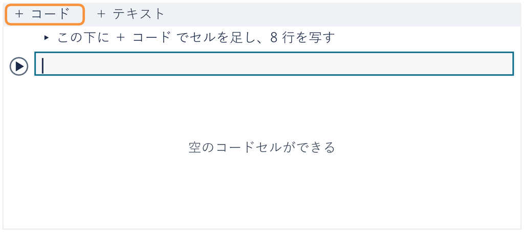

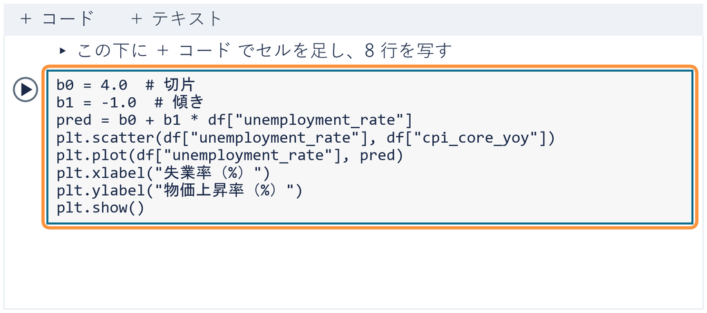

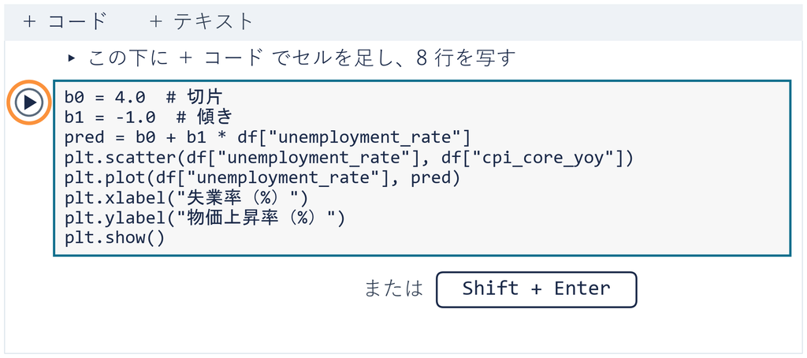

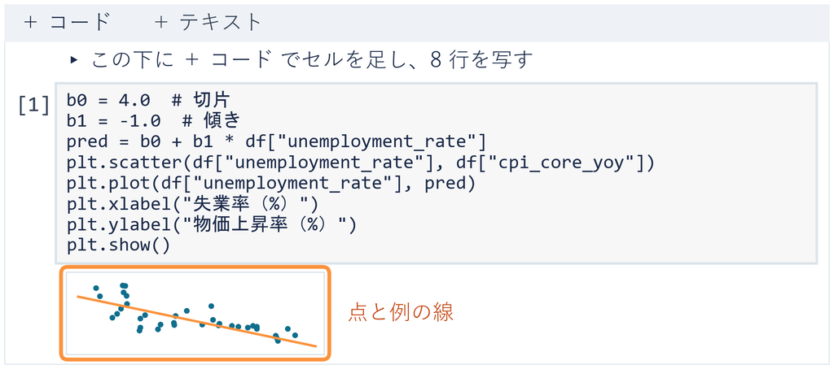

⏸ PAUSE 動画を止めて $2$ 分。線が出たら再生に戻る

## 演習 3-1-2 傾きの変更

演習 3-1-2

傾きを −0.5 にすると、線の値はどうなるか

```python
b0 = 4.0  # 切片
b1 = -1.0  # 傾き
x = 3.0
yhat = b0 + b1 * x
print(yhat)
```

1. **先に考える**：ⓐ 1.0 より大きくなる ⓑ 1.0 より小さくなる
2. **写して変える**：**＋ コード**で写し、2 行目を `b1 = -0.5` に
3. **終わり**：答え欄に ⓐ か ⓑ と、出た数を書く（`yhat`＝線の値）

⏸ PAUSE 動画を止めて $3$ 分。答えを書いたら再生に戻る

## 演習 3-1-2 の答え

答えは **ⓐ 2.5**。4.0 − 0.5 × 3.0 ＝ 2.5（傾き −1.0 なら 1.0）

[figure not shown]

マイナスを外した大きさ（1.0 → 0.5）が小さいほど、線はゆるい

## まとめ

- 散布図は、2 つの列の組を 1 行 1 点で表した図
- 横は説明に使う列 $x$、縦は当てたい列 $y$
- 単回帰の直線は $\hat{y} = \hat{\beta}_0 + \hat{\beta}_1 x$。傾きは $x$ が 1 増えたときの $\hat{y}$ の動き
- 5 人の線 $12 - 2x$：1 日多い人ほど、平均して 2 時間短い
- 36 年の傾きの単位は %ポイント。言えるのは、  
  一緒に動いたところまで

線は何本でも引ける。次は、どの線を選ぶか

経済データとプログラミングII

第3回 — Topic02

最小二乗法

なぜ「二乗」して足すのか？

## 第3回の道のり

1

線を引く

演習 3-1

散布図と例の線

2

線の選び方

写経

二乗和を出す

3

機械に引かせる

演習 3-3

予測と二乗和

4

当たり具合

演習 3-4

期間と決定係数

いまココ — ずれを数にして、いちばん小さい 1 本を選ぶ

## このトピックで学ぶこと

- **何をやるか**：点と線の**ずれ**を数にして、いちばんましな 1 本を選ぶ
- **なぜ**：目で選ぶと人によって違う。  
  数にすれば誰がやっても同じ 1 本
- **いつ必須か**：この選び方は、  
  このあと出てくる道具にも同じ形で入る
- **最後に**：36 年で、例の線の二乗和を Python で出す

問い：架空の 5 人のバイト日数と自習時間。いちばんましな線はどれ？

## 平均の点を通る 4 本の線

[figure not shown]

平均の点＝日数 (1+2+3+4+5)÷5＝3・時間 (9+10+6+2+3)  
÷5＝6。4 本ともここを通る

## ◼ 残差と二乗和

定義

**残差**

＝

実測の値 $y$ − 線の値 $\hat{y}$

**二乗和**

＝

残差を 1 つずつ二乗して、全部足した数

**最小二乗法**

＝

二乗和がいちばん小さい直線を選ぶ決め方

- **線の値 $\hat{y}$**：その人の $x$ を直線の式に入れて出した値
- **残差の向き**：点が線より上なら $+$、下なら $-$。  
  図では点から線へ下ろす縦線

次のページで、二乗和を出す手順を STEP に分ける

## ◼ 最小二乗法の手順

手順

**STEP 1** 各点の $x$ を直線に入れて、**線の値** $\hat{y}$ を出す  
**STEP 2** **残差** $y - \hat{y}$ を出す  
**STEP 3** 残差を 1 つずつ**二乗**する  
**STEP 4** 全部足して**二乗和**にする  
線を変えて STEP 1〜4 をくり返し、  
**二乗和がいちばん小さい直線**を選ぶ

次のページから、架空の 5 人の表で STEP 1 から順に

## STEP 1・2 平均の線と残差

[figure not shown]

架空の 5 人の 1 週間。まず、全員に平均の 6 時間と言う水平の線で

## STEP 3・4 二乗と和

[figure not shown]

二乗は、1 辺が残差の大きさの正方形の面積。下向きの −4 も 16 と数える

## ✋ たしかめ 傾きと残差の和

たしかめ

STEP 3 を飛ばし、残差をそのまま足すと、和はどうなるか

線は 4 本。どれも平均の点（3 日・6 時間）を通り、傾きは 0・−1・−2・−3

1. 予想を 1 つ選ぶ — ⓐ 当たる線ほど小さい ⓑ どの線でも 0  
   ⓒ 当たる線ほど大きい
2. 手がかり：平均の線の残差 +3・+4・0・−4・−3 の和

⏸ PAUSE 動画を止めて $1$ 分。予想を決めたら再生に戻る

## たしかめの答え

[figure not shown]

答えは ⓑ。4 本とも**平均の点を通るように選んだ**から、  
上と下のずれが打ち消し合って 0

## 残差の和が 0 になる仕組み

傾き −1 の線で、合計を先に出してから引く

時間の合計

$9 + 10 + 6 + 2 + 3$

$= 30$

5 人の実際の時間を足す

線の値の合計

$8 + 7 + 6 + 5 + 4$

$= 30$

6 を真ん中に、上と下へ同じだけ

残差の和

$30 - 30$

$= 0$

合計どうしを引く

平均の点を通る線なら、線の値の合計はいつも 5 人 ×  
6 時間 ＝ 30。だから和は 0

## 和で比べた 2 本の線

[figure not shown]

和では、ひどい線のほうが良く見える。打ち消し合うので、  
**和は当たり具合を表さない**

## よくある失敗 残差の和による線選び

問い：残差を足して、和が小さい線を選べばよいか

✕ 残差の和で選ぶ

ずれが小さいほど、  
良い線に見える  
でも、ひどい線で和 0、  
良い線で和 −5

○ 二乗してから足す

STEP 3 を飛ばさない  
上のずれも下のずれも、  
正の数にして足す

上と下が打ち消し合うので、和は当たり具合を表さない。  
線の良し悪しは二乗和で見る

## 二乗してから足す理由

**① 符号を消す** — 傾き −2 の線の B さんと D さんで

$(+2) + (-2)$

$= 0$

そのまま足すと打ち消す

$(+2)^2 + (-2)^2$

$= 8$

二乗すれば、どちらも正

**② 大きい残差ほど、重く数える** — 残差が 2 倍なら、数え方は 4 倍

$2^2$

$= 4$

残差 $2$ は、$4$ と数える

$4^2$

$= 16$

残差 $4$ は、$16$ と数える

符号を消すだけなら**絶対値**（マイナスを外して大きさだけ見る）でもよい。  
二乗を選ぶのは、機械に解かせやすいから  
裏返すと、**極端に外れた 1 点に引っ張られやすい**

## 傾きを動かした二乗和

[figure not shown]

傾き −1 なら 残差 +1・+3・0・−3・−1 → 1 + 9 + 0 + 9 + 1 ＝ 20  
二乗和は傾き −2 で底

## 最小二乗の直線

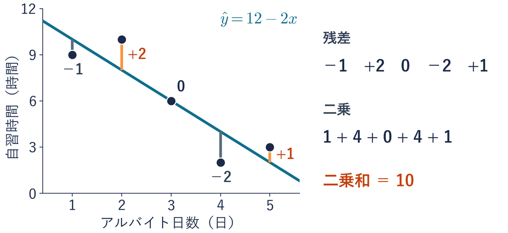

底の線は 12 − 2x（切片 6 ＋ 2 × 3 ＝ 12）。切片をずらすと、  
二乗和は 10 より大きくなる

## 失業率と物価上昇率の表

今度は架空の 5 人ではなく、**日本の 36 年**をくらべる

| 年 | 失業率（%）$x$ | 物価上昇率（%）$y$ |
| --- | --- | --- |
| 1991 | 2.09 | 2.88 |
| 1992 | 2.15 | 2.25 |
| 1993 | 2.50 | 1.26 |
| ⋮ | ⋮ | ⋮ |

1 行＝1 年で 36 行（1991〜2026 年の年平均）。  
5 人の表の 1 行＝1 人と同じ読み方

## デモ：最小二乗の実験室

数の話

残差 ＝ 実測 y − 線の値 ŷ  
残差を二乗して全部足した二乗和が、  
いちばん小さい 1 本を選ぶ

- **何を見るか**：自分の線と、機械が選んだ線の二乗和を比べる
- **図の意味**：上に散布図と残差の縦線、下に残差の棒
- **操作**：タブ 3 つ、つまみ 2 本（切片・傾き）、fit

ミッション 二乗和がいちばん小さい線を手で探し、  
fit の二乗和と比べる

※ 次のスライドへ進むときは、デモの枠の外を一度クリックしてから ← → キーを押す

[interactive chart not shown]

## 機械が選んだ 1 本

[figure not shown]

5 人のときと同じ順（点 → 線 → 残差 → 二乗和）に読む。  
外れの大きい年は 2023 年と 2020 年

## 写経 残差と二乗和のコード

```python
b0 = 4.0  # 切片
b1 = -1.0  # 傾き
pred = b0 + b1 * df["unemployment_rate"]
resid = df["cpi_core_yoy"] - pred
ssr = (resid ** 2).sum()
print(round(ssr, 2))
```

| 行 | 部品 | すること | できるもの |
| --- | --- | --- | --- |
| 1-2 | **切片と傾き** | 例の線の 2 つの数を入れる | 切片 `b0`・傾き `b1` |
| 3 | **STEP 1 線の値** | 失業率を線の式に入れる | 36 個の線の値 `pred` |
| 4 | **STEP 2 残差** | 実測から `pred` を引く | 36 個の残差 `resid` |
| 5 | **STEP 3・4** | `** 2` で二乗、`.sum()` で和 | 二乗和 `ssr` |
| 6 | **表示** | 小数第 2 位まで `round` | 23.35 と出る |

※ `df` は準備のセルで作った 36 行の表。`ssr` は二乗和の英語の頭文字  
※ **`"` は半角。全角の `”` だとエラー**

## コードセルの写経と実行

1. **＋ コード**で空の  
   セルを足す
2. 6 行を上から写す
3. **▶** か **Shift + Enter** で実行  
   （Mac は Shift + return）
4. 出力の **23.35** を見る

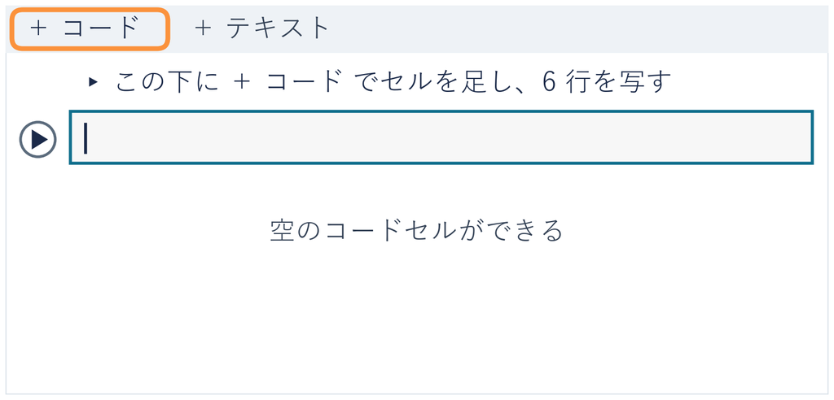

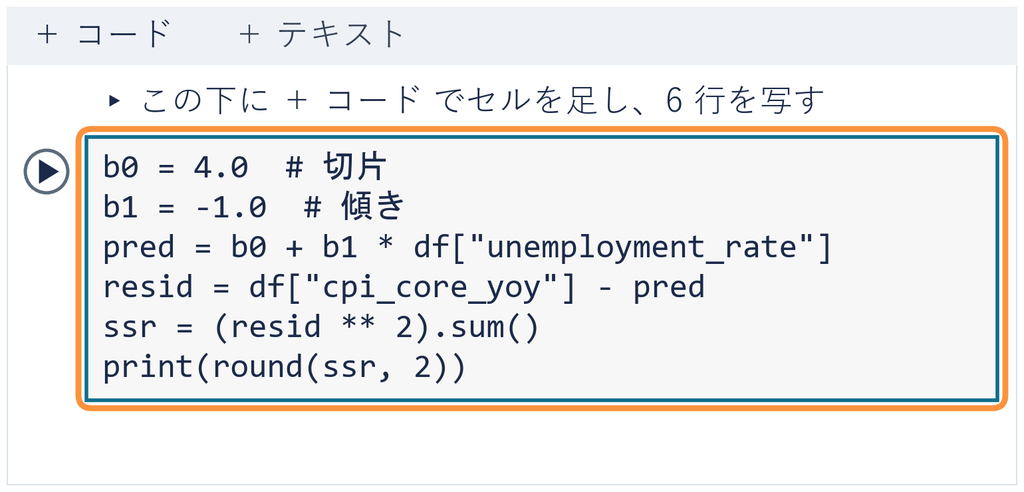

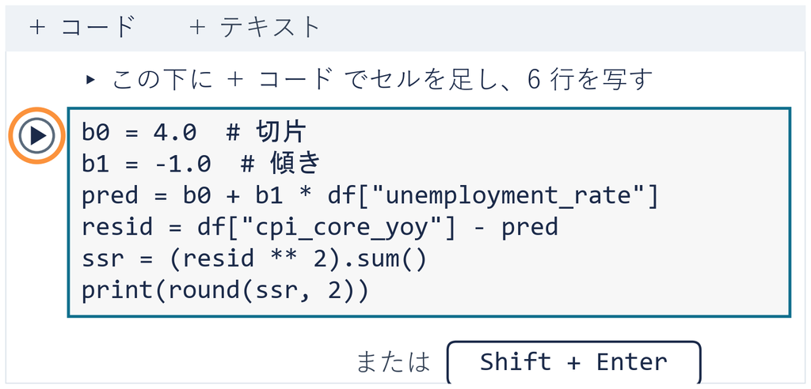

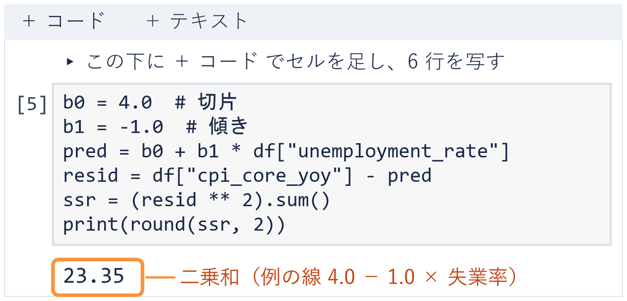

⏸ PAUSE 動画を止めて $2$ 分。23.35 が出たら再生に戻る

## 写経の出力

[figure not shown]

23.35 は、例の線から 36 本の縦線を二乗して足した数。  
5 人の表の 50 や 10 と同じ数え方

## Q&A

Q1 `NameError: name 'df' is not defined` と出た

ノートを開き直すと表 `df` は消える。  
**準備のセル**から上へ順に実行し直す

Q2 `KeyError: 'unemployment_rate'` と出た

列名の打ち間違い。CSV の列名のまま、半角で写す

Q3 `SyntaxError` と出て、`”` の所に印が付いた

`"` が全角になっている。**半角の `"`** に打ち直す

Q4 23.35 と違う数が出た

1・2 行目の `b0 = 4.0`・`b1 = -1.0` を見直す。  
数と、半角のマイナス `-`

## まとめ

- 残差 ＝ 実測 $y$ − 線の値 $\hat{y}$。点から線へ下ろす縦線
- 手順は 線の値 → 残差 → 二乗 → 足す。二乗和が最小の直線を選ぶ
- 残差の和は上と下が打ち消し合い、  
  当たり具合を表さない。だから二乗する
- 5 人の表では傾き −2・二乗和 10 が底。36 年では二乗和 22.13 の線
- コードは STEP と同じ順。切片は `b0`、傾きは `b1`

白書や論文の「最小二乗法で推定した」は、この選び方  
手で探すのは大変。次は機械に線を引かせる

経済データとプログラミングII

第3回 — Topic03

statsmodels による回帰

3 STEP で、手で探した線が出る

## 第3回の道のり

1

線を引く

演習 3-1

散布図と例の線

2

線の選び方

写経

二乗和を出す

3

機械に引かせる

演習 3-3

予測と二乗和

4

当たり具合

演習 3-4

期間と決定係数

いまココ — 二乗和がいちばん小さい線を、機械に出させる

## このトピックで学ぶこと

- **何をやるか**：二乗和が最小の線を、  
  Python の道具 **statsmodels** で出す
- **なぜ**：二乗和の底を手で探すのは大変。機械なら 3 行
- **いつ必須か**：レポートで係数を書くときは、  
  この道具が返す数から写す
- **最後に**：36 年の線で予測し、その線の二乗和を例の線とくらべる

問い：5 人の表を機械に渡すと、手で見つけた 12 と −2 が出る？

## チルダによる式の書き方

用語

`"y ~ x"` ＝ 「**$y$ を $x$ で説明する**」  
と書いた式。`~` の読みは**チルダ**

- **左が当てたい列**：5 人の表なら `y`（自習時間）
- **右が説明に使う列**：5 人の表なら `x`（日数）
- **列名をそのまま書く**：表の列の名前を、`" "` の中に書く
- **切片は書かない**：**切片（$\hat{\beta}_0$）は自動で入る**

`~` の打ち方は **Shift ＋ ^**（日本語キーボードの、山の形の記号のキー）

左右の順が、そのまま「何を、何で説明するか」になる

## ◼ statsmodels の 3 STEP

手順

**STEP 1** `smf.ols("y ~ x", data=表)` で**式を書く**  
**STEP 2** `.fit()` で**当てはめる**（二乗和がいちばん小さい線を探す）  
**STEP 3** `.params` で**切片と傾きを読む**

- **`smf`**：statsmodels の、式で書く道具のあだ名（すぐあとの準備のセルで呼ぶ）
- **`ols`**：**Ordinary Least Squares**（＝最小二乗法）の頭文字
- **`data=表`**：どの表から列を探すかを渡す

3 つとも飛ばせない。式を書く → 当てはめる → 読む

## 5 人の表の 3 STEP

[figure not shown]

手で探した二乗和の底と同じ線を、機械は 3 STEP で返した

## 36 年の 3 STEP の結果

今度は 36 年の表 `df` を、同じ 3 STEP に通す

当てはめた直線

**物価上昇率 $\approx 3.614 - 0.859 \times$ 失業率**

- **`Intercept` の 3.614**：切片 $\hat{\beta}_0$。`Intercept` ＝ 切片
- **`unemployment_rate` の −0.859**：傾き $\hat{\beta}_1$。行の名前は列名
- **読み方**：失業率が 1 ポイント高い年は、  
  物価上昇率が平均して 0.859 ポイント低い
- **桁**：コードを動かすと画面には 3.613879・−0.858822。  
  ここは小数第 3 位に丸めた値

## summary の表で読む 2 か所

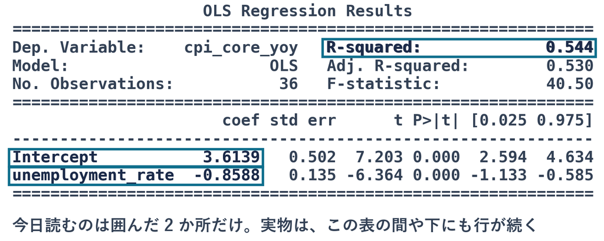

`.summary()` で出る表。右上の `R-squared` は場所だけ確かめる。意味は次のトピックで

## ◼ 直線による予測

式

予測（＝線の値 $\hat{y}$）＝ 切片 ＋ 傾き × $x$

**今回は**（失業率 3.0% の年）

$\hat{y}$

$= 3.614 + (-0.859) \times 3.0$

2 つの数と 3.0 を入れる

$= 3.614 - 2.577$

掛け算を先に

$= 1.037$

引く

$\approx 1.04$

小数第 2 位に丸める

失業率 3.0% の年の物価上昇率を、直線は 1.04% と言う

## statsmodels の準備のセル

```python
import statsmodels.formula.api as smf
```

**写経せず、そのまま実行するセル**  
statsmodels の、式で書く道具を `smf` の名前で呼ぶ  
`import` ＝ 道具を呼ぶ・`as` の後ろ ＝ あだ名  
`df` は最初の準備のセルで作った 36 行の表。  
ノートを開き直したら、上から順に実行し直す

## 写経 1 5 人の表の 3 STEP

```python
d = pd.DataFrame({"x": [1, 2, 3, 4, 5],
                  "y": [9, 10, 6, 2, 3]})
model = smf.ols("y ~ x", data=d)
res = model.fit()
print(res.params)
```

| 行 | 部品 | 渡すもの | 返ってくるもの・起きること |
| --- | --- | --- | --- |
| 1-2 | **表を作る** `pd.DataFrame` | 列の名前と、値の並び | 5 人の表に `d` の名前 |
| 3 | **STEP 1 式を書く** `smf.ols` | 式 `"y ~ x"` と表 `d` | 式を書いた模型に `model` の名前 |
| 4 | STEP 2 当てはめる `.fit()` | 何も渡さない | 当てはめた結果に `res` の名前 |
| 5 | **STEP 3 読む** `.params` | 何も渡さない | 切片と傾きがセルの下に出る |

※ `{ }` の中は「列の名前: 値の並び」 ※ **`"` は半角。全角の `”` だとエラー**

## 3 STEP の写経と実行

1. **＋ コード**で空のセルを足す  
   （案内の文の下）
2. 写経 1 の 5 行を上  
   から写す
3. **▶** か **Shift + Enter** で実行  
   （Mac は Shift + return）
4. セルの下に **12.0** と **−2.0**  
   が出るかを見る

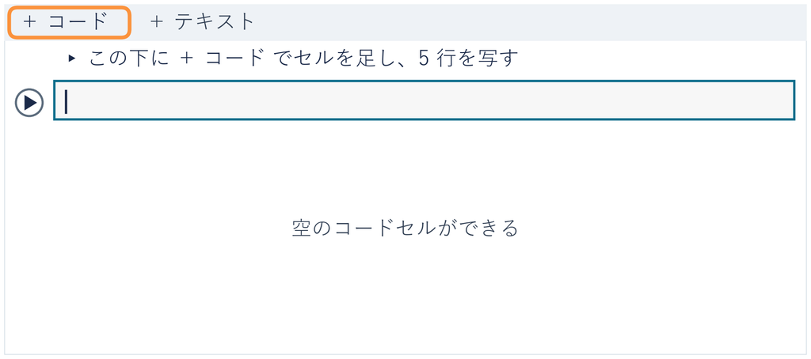

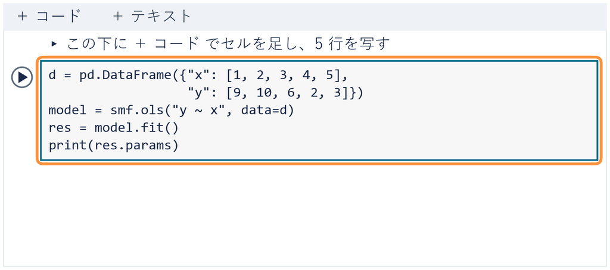

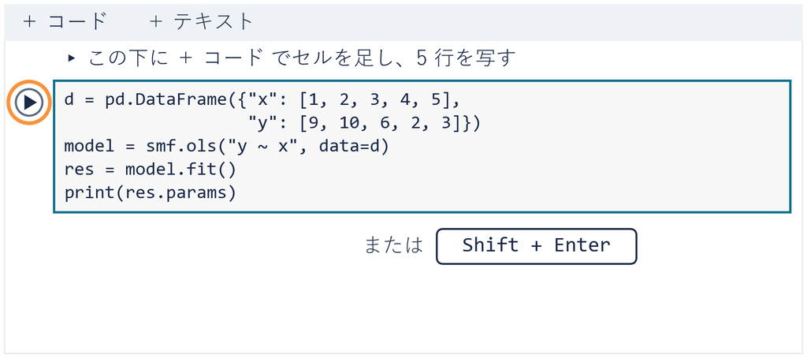

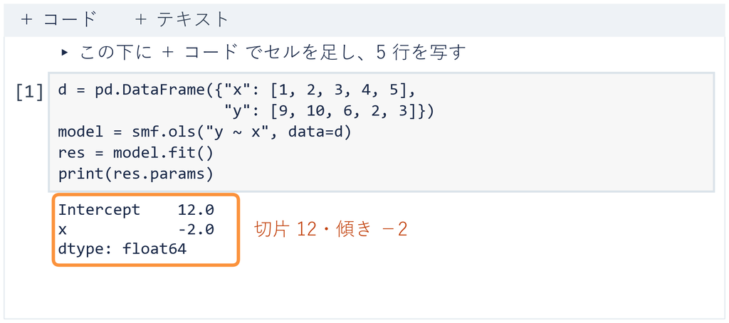

⏸ PAUSE 動画を止めて $2$ 分。2 つの数が出たら再生に戻る

## 写経 2 36 年の 3 STEP と予測

```python
model = smf.ols("cpi_core_yoy ~ unemployment_rate", data=df)
res = model.fit()
print(res.params)
b0 = res.params["Intercept"]
b1 = res.params["unemployment_rate"]
print(round(b0 + b1 * 3.0, 2))
```

| 行 | 部品 | 渡すもの | 返ってくるもの・起きること |
| --- | --- | --- | --- |
| 1 | **STEP 1** | 式の列名と表 `df`（写経 1 と違う所） | 模型 `model` |
| 2-3 | **STEP 2・3** | 写経 1 と同じ | 切片と傾きが出る |
| 4-5 | **数に名前** | `params` の行の名前 | 切片に `b0`、傾きに `b1` |
| 6 | **予測** | 切片 ＋ 傾き × 3.0 | 小数第 2 位で 1.04 |

⏸ PAUSE 動画を止めて $2$ 分。1.04 が出たら再生に戻る

## 写経 2 の出力

[figure not shown]

3.613879 と −0.858822 が切片と傾き。最後の 1.04 が失業率 3.0% の予測

## 2 つの写経に共通の形

[figure not shown]

決まった 3 つの部品を、順にはめるパズル。変わるのは式と表だけ

## summary の表を出すセル

```python
print(res.summary())
```

**写経せず、そのまま実行するセル**  
前に見た `summary` の表が、自分の画面にも出る  
`coef` 列の 2 つの数が、写経 2 の `params` と同じかを見る

## 演習 3-3-1 予測する失業率の変更

演習 3-3-1

失業率 3.0% を 5.0% にすると、予測はどうなるか

```python
b0 = res.params["Intercept"]
b1 = res.params["unemployment_rate"]
print(round(b0 + b1 * 3.0, 2))
```

1. **先に考える**：ⓐ 1.04 より大きくなる ⓑ 1.04 より小さくなる
2. **写して変える**：案内の下に **＋ コード** でセルを足して写す  
   3 行目の `3.0` を `5.0` に（1 か所）。写経のセルは残す
3. **終わり**：答え欄に ⓐ か ⓑ と、出た数を書く

⏸ PAUSE 動画を止めて $3$ 分。答えを書いたら再生に戻る

## 演習 3-3-1 の答え

答えは **ⓑ −0.68**（物価が下がる、と直線は言う）。1.04 から 1.72 下がった

[figure not shown]

失業率が 2 ポイント上がると、予測は 2 × 0.859 ≈ 1.72 下がる  
傾きの読みそのもの

## 演習 3-3-2 機械の線の二乗和

演習 3-3-2

機械の線の二乗和は、例の線の 23.35 より小さいか

```python
b0 = 4.0  # 切片
b1 = -1.0  # 傾き
pred = b0 + b1 * df["unemployment_rate"]
resid = df["cpi_core_yoy"] - pred
ssr = (resid ** 2).sum()
print(round(ssr, 2))
```

1. **先に考える**：ⓐ 小さくなる ⓑ 大きくなる
2. **写して変える**：1・2 行目を写経 2 と同じ `res.params` に
3. **終わり**：答え欄に ⓐ か ⓑ と、出た数を書く

⏸ PAUSE 動画を止めて $3$ 分。答えを書いたら再生に戻る

## 演習 3-3-2 の答え

[figure not shown]

答えは ⓐ 22.13。  
機械の線より二乗和が小さい線は無い。これが最小二乗の直線

## Q&A

Q1 `NameError` で `smf` や `pd` が無いと出た

**準備のセル**（最初のと statsmodels の）を上から実行

Q2 `~` が打てない

日本語キーボードは **Shift ＋ ^**。全角の `～` ではなく半角の `~`

Q3 `PatsyError` と出た

式の中の列名の打ち間違い。CSV の列名のまま写す

Q4 `KeyError` と出た

行の名前（`Intercept`・列名）を 1 文字ずつ同じに。I は大文字

Q5 `SyntaxError` と出た

かっこの閉じ忘れ。開いた数と閉じた数をそろえる

## まとめ

- `"y ~ x"` は「$y$ を $x$ で説明する」と書いた式
- **STEP 1** 式を書く → **STEP 2** `.fit()` → **STEP 3** `.params`
- 5 人の表では 12・−2。手で探した二乗和の底と同じ線
- 36 年では切片 3.614・傾き −0.859。予測は 切片 ＋ 傾き × 失業率
- その線の二乗和 22.13 は、例の線の 23.35 より小さい
- 2 つの写経で変わったのは、式と表だけ

`summary` の右上に `R-squared 0.544` がある。次は、その数の意味から

経済データとプログラミングII

第3回 — Topic04

決定係数 $R^2$

この直線、どれくらい当たっている？

## 第3回の道のり

1

線を引く

演習 3-1

散布図と例の線

2

線の選び方

写経

二乗和を出す

3

機械に引かせる

演習 3-3

予測と二乗和

4

当たり具合

演習 3-4

期間と決定係数

いまココ — 当たり具合を、$0$ から $1$ の数 1 つにする

## このトピックで学ぶこと

- **何をやるか**：直線の**当たり具合**を、0 から 1 の数 1 つにする
- **なぜ**：「だいたい合っている」では、2 本の直線を比べられない
- **いつ必須か**：直線を出したら、必ず添える数
- **土台**：二乗和。平均の線と直線で、外れの大きさをくらべる

問い：5 人の線 12 − 2x は、平均の線よりどれだけ当たっている？

## ◼ 決定係数

定義

**決定係数 $R^2$**（$R^2$ で 1 つの記号）＝平均の線の
外れ（残差の二乗和）のうち、直線で消えた割合
$$R^2 = 1 - \frac{\text{直線の二乗和}}{\text{平均の線の二乗和}}$$

- **平均の線**：全員に $y$ の平均を言う水平の線（傾き 0 の線）
- **$R^2 = 1$**：直線の二乗和が 0。全部の点が直線の上
- **$R^2 = 0$**：直線の二乗和が平均の線と同じ。直線が何も足していない
- **範囲**：切片のある最小二乗の直線なら、0 から 1 のあいだ

分母は「何も説明しないときの外れ（二乗和）」。  
それを基準に、減った分を見る

## ◼ 決定係数の求め方

手順

**STEP 1** 平均の線の二乗和を出す  
**STEP 2** 直線の二乗和を出す  
**STEP 3** 1 − STEP 2 の数 ÷ STEP 1 の数

次のページから、架空の 5 人の表で STEP 1 から順に

## STEP 1・2 5 人の 2 本の線

[figure not shown]

平均の線は、最小二乗法のトピックの傾き 0 の線（50）。直線 12 − 2x は 10

## STEP 3 5 人の決定係数

**今回は**（平均の線 50・直線 10）

$R^2$

$= 1 - \frac{10}{50}$

STEP 1・2 の数を入れる

$= 1 - 0.2$

割り算を先に

$= 0.8$

引く

平均の線の外れ（二乗和）のうち、8 割を直線が消した

## 外れの 8 割が消えた棒

[figure not shown]

50 のうち 40 が消え、10 が残った。40 ÷ 50 ＝ 0.8 が決定係数

## 36 年の 2 本の線

今度は 36 年。同じ STEP 1・2 で、二乗和を 2 つ出す

[figure not shown]

平均の線 48.48 → 直線 22.13。5 人のときと同じ順に読む

## ★ 36 年の決定係数

**今回は**（平均の線 48.48・直線 22.13）

$R^2$

$= 1 - \frac{22.13}{48.48}$

STEP 1・2 の数を入れる

$\approx 1 - 0.456$

割り算を先に（小数第 3 位）

$= 0.544$

引く

`summary` の右上の `R-squared 0.544` は、この数。  
外れの半分ちょっとを、失業率 1 つで消した

## よくある失敗 決定係数の読み違え

✕ 物価の $54\%$ は失業率で決まっている

$R^2$ が $0.544$ なので、  
半分は失業率のせい

割合の数なので、  
そう読みたくなる

○ 消えたのは「外れ」

言えるのは、平均の線の外れが  
54% 減ったことだけ

物価の動きの 54% が失業率の  
せい、とは**言っていない**

$R^2$ は当てはまりの物差しであって、原因を分けた数ではない

## 写経 決定係数のコード

```python
model = smf.ols("cpi_core_yoy ~ unemployment_rate", data=df)
res = model.fit()
print(res.rsquared)
```

| 行 | 部品 | 渡すもの | 返ってくるもの・起きること |
| --- | --- | --- | --- |
| 1-2 | **statsmodels の STEP 1・2** | 前のトピックの写経 2 と同じ | 当てはめた結果 `res` |
| 3 | statsmodels の STEP 3 を替える | `params` を `rsquared` に（1 語） | 決定係数がセルの下に出る |

※ 出るのは 0.5436 から始まる小数（下の桁まで続く） ※ `"` は半角

## 決定係数の写経と実行

1. **＋ コード**で空のセルを足す  
   （案内の文の下）
2. 前のページの 3 行を上  
   から写す
3. **▶** か **Shift + Enter** で実行  
   （Mac は Shift + return）
4. 0.5436 から始まる数が  
   出るかを見る

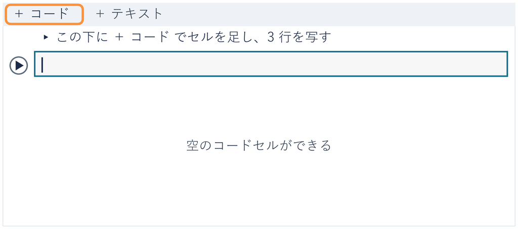

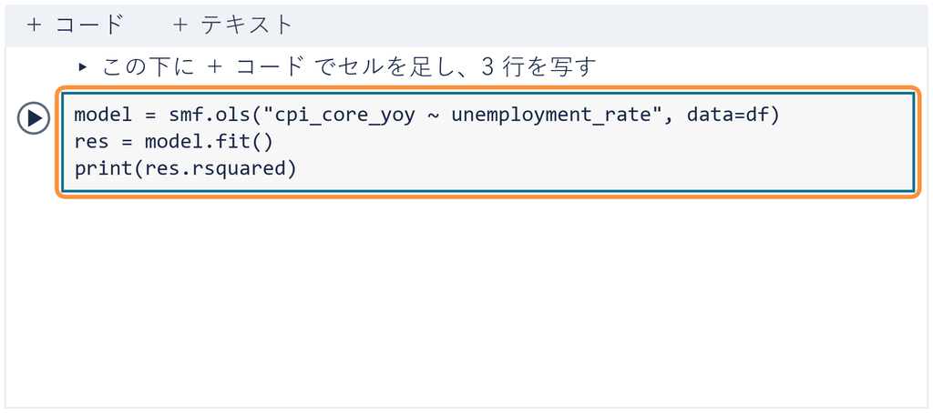

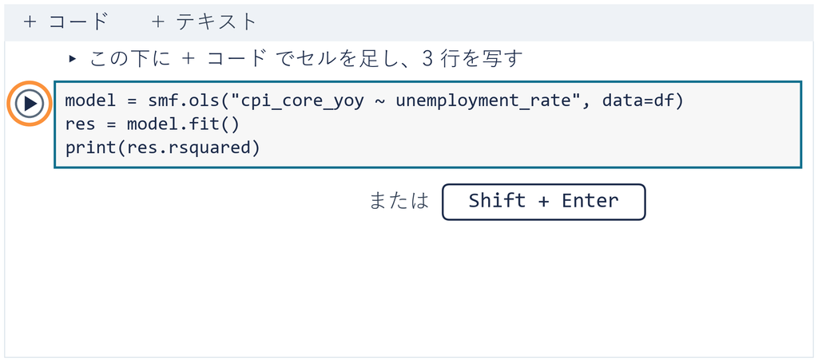

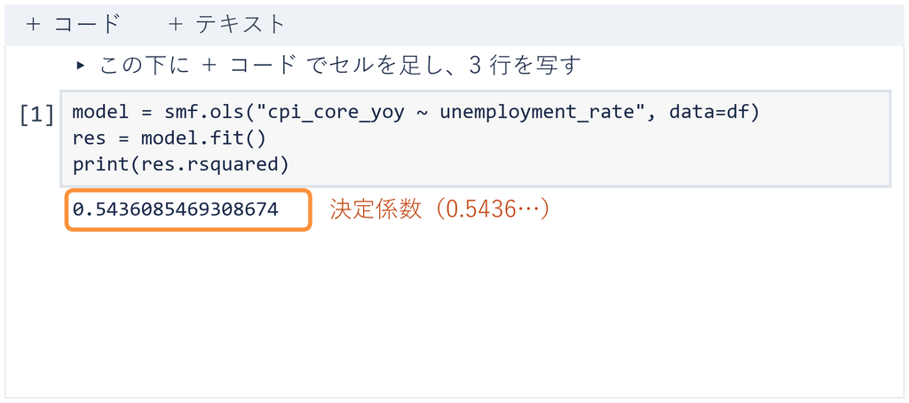

⏸ PAUSE 動画を止めて $2$ 分。数が出たら再生に戻る

## ✋ たしかめ 期間を切った決定係数

たしかめ

2013〜2019 年の 7 年だけで statsmodels の 3 STEP  
を回すと、決定係数は

手がかり — この 7 年、失業率は動いたが、  
**物価上昇率はほとんど動いていない**

1. 36 年の 0.544 とくらべて予想を 1 つ —  
   ⓐ ほぼ同じ ⓑ 高い ⓒ ぐっと低い
2. 選んだ理由を、一言で言えるようにしておく

⏸ PAUSE 動画を止めて $1$ 分。PC は使わない。予想を決めたら再生に戻る

## 期間の表を作るセル

```python
early = df.loc["1991":"1999"]
late = df.loc["2013":"2019"]
print(len(early), len(late))
```

| 行 | 書き方 | 意味 |
| --- | --- | --- |
| 1 | `df.loc["1991":"1999"]` | 1991〜1999 年の行だけを取り出し、`early` の名前 |
| 2 | `df.loc["2013":"2019"]` | 2013〜2019 年の行だけを取り出し、`late` の名前 |
| 3 | `len` | 行の数。`9 7` と出る |

**写経せず、そのまま実行するセル**。`.loc` ＝ 場所（location）の頭 3 文字  
行の名前が日付なので、年の文字で期間を切り出せる

⏸ PAUSE 動画を止めて実行。9 7 が出たら再生に戻る

## 演習 3-4 期間を替えた決定係数

演習 3-4

表を 2013〜2019 年の `late` にすると、決定係数は

```python
model = smf.ols("cpi_core_yoy ~ unemployment_rate", data=df)
res = model.fit()
print(res.rsquared)
```

1. **写して変える**：**＋ コード** で足したセルに写す  
   `data=df` を `data=late` に（1 か所）。  
   もう 1 つセルを足し、`data=early` でも
2. **終わり**：答え欄に予想の記号と 2 つの数（小数第 2 位まで）

⏸ PAUSE 動画を止めて $4$ 分。2 つの数を書いたら再生に戻る

## 演習 3-4 の答え

答えは **ⓒ ぐっと低い**。1991〜1999 年は 0.72、2013〜2019 年は 0.02

[figure not shown]

2013〜2019 年は物価上昇率がほとんど動かない。  
動かない相手は、直線で説明できない

## 決定係数の読み方

読み方

決定係数は、**その期間のそのデータで**、  
平均の線の外れを直線がどれだけ消したか

- **言えること**：その期間で、直線が平均の線よりどれだけ当たったか
- **言えないこと**：原因の取り分。ほかの期間でも当たるか
- **使える場面**：記事で「決定係数 0.8 の高い説明力」と見たら、  
  どの期間のデータかを見る

同じ手法でも、期間で 0.72 にも 0.02 にもなる

## まとめ

- 決定係数 $R^2 = 1 -$ 直線の二乗和 ÷ 平均の線の二乗和
- 5 人の表では 1 − 10/50 ＝ 0.8。外れの 8 割が消えた
- 36 年では 1 − 22.13/48.48 ≈ 0.544。コードは `.rsquared` の 1 語
- 測るのは外れの減り方で、原因の取り分ではない
- 期間を替えると、0.72 にも 0.02 にもなる

決定係数を見たら、どの期間のデータかを必ず見る

## 第 3 回のまとめ

線を引く散布図に、切片と傾きで 1 本の線

選ぶ二乗和がいちばん小さい線（最小二乗法）

機械に引かせるstatsmodels の 3 STEP

当たり具合決定係数。平均の線の外れが消えた割合

傾き −0.859 そのものを、どこまで信じてよいか。それはまだ答えていない